# Dog breeds report (final assignment)

Author

Alba Neher-Mestre

# Final assignment for Projects in R course

## Introduction

We have a family willing to adopt a dog from the kennel. They have asked for help because of their special necessities as a family. There are 3 members:

- **Mother** (42yo):
  - Familiar only source of income
  - No time to take the dog twice to walk
- **Father** (43yo):
  - Physical disability
  - Not strong enough to walk a large breed
- **Son** (10yo):
  - Diagnosed with autism with noise hiper-sensibility.

Given these circumstances we need to find a suitable dog breed for them.

## Data

We check some traits that describe dogs and we have obtained the data from *tidytuesday* GitHub “data/2022/2022-02-01/breed_traits.csv”.

## Analysis

```r
#load libraries
library(tidyverse)
library(lubridate)
library(here)
library(unibeCols)
```

```r
# Load and read data
Dog_data <- read_csv(here("data/raw/breed_traits.csv"))
```

### Trait selection

For this family we have to keep in mind three characteristics that will translate into our interesting breed traits. These traits will be useful to select the most suitable dog breed for the adoption. These traits are ranked from 1 to 5, being 1 the lowest and 5 the highest levels. We will focus on these three traits:

- **Energy**: low, no need to walk twice a day or use a lot of strength
- **Adaptability**: high, they need to adapt to a constant changing environment
- **Barking level**: low, due to noise hiper-sensitivity of the child

```r
# Check data
head(Dog_data)
```

| Breed | Affectionate With Family | Good With Young Children | Good With Other Dogs | Shedding Level | Coat Grooming Frequency | Drooling Level | Coat Type | Coat Length | Openness To Strangers | Playfulness Level | Watchdog/Protective Nature | Adaptability Level | Trainability Level | Energy Level | Barking Level | Mental Stimulation Needs |
| --- | --- | --- | --- | --- | --- | --- | --- | --- | --- | --- | --- | --- | --- | --- | --- | --- |
| Retrievers (Labrador) | 5 | 5 | 5 | 4 | 2 | 2 | Double | Short | 5 | 5 | 3 | 5 | 5 | 5 | 3 | 4 |
| French Bulldogs | 5 | 5 | 4 | 3 | 1 | 3 | Smooth | Short | 5 | 5 | 3 | 5 | 4 | 3 | 1 | 3 |
| German Shepherd Dogs | 5 | 5 | 3 | 4 | 2 | 2 | Double | Medium | 3 | 4 | 5 | 5 | 5 | 5 | 3 | 5 |
| Retrievers (Golden) | 5 | 5 | 5 | 4 | 2 | 2 | Double | Medium | 5 | 4 | 3 | 5 | 5 | 3 | 1 | 4 |
| Bulldogs | 4 | 3 | 3 | 3 | 3 | 3 | Smooth | Short | 4 | 4 | 3 | 3 | 4 | 3 | 2 | 3 |
| Poodles | 5 | 5 | 3 | 1 | 4 | 1 | Curly | Long | 5 | 5 | 5 | 4 | 5 | 4 | 4 | 5 |

```r
# Select interesting traits for this family
Interesting_Traits <- Dog_data |> select("Breed", "Barking Level", "Adaptability Level", "Energy Level")
show(Interesting_Traits)
```

```
# A tibble: 195 × 4
   Breed                     `Barking Level` `Adaptability Level` `Energy Level`
   <chr>                               <dbl>                <dbl>          <dbl>
 1 Retrievers (Labrador)                   3                    5              5
 2 French Bulldogs                         1                    5              3
 3 German Shepherd Dogs                    3                    5              5
 4 Retrievers (Golden)                     1                    5              3
 5 Bulldogs                                2                    3              3
 6 Poodles                                 4                    4              4
 7 Beagles                                 4                    4              4
 8 Rottweilers                             1                    4              3
 9 Pointers (German Shortha…               3                    4              5
10 Dachshunds                              5                    4              3
# ℹ 185 more rows
```

### Breed selection

```r
# Selecting our candidate breeds by filtering variables' levels
Interesting_Traits_Filtered <- subset(Interesting_Traits,
                                     `Barking Level` <= 2 &
                                     `Adaptability Level` > 4 &
                                     `Energy Level` <= 3)
unique(Interesting_Traits_Filtered$Breed)
```

```
[1] "French Bulldogs"     "Retrievers (Golden)" "Pugs"
```

The only breeds that fulfill these conditions are: French Bulldogs, Golden Retrievers and Pugs. When asking the family directly, they wanted to know the probabilities of these breeds needing medical attention. Due to their own medical necessities, this family wants a dog that will not require a significant economic investment in veterinary care. Therefore, we checked for a public published data set in which we could compare the number of overall veterinary visits and their reasons for these breeds. This dataset was obtained from: **Kim E, Choe C, Yoo JG, Oh SI, Jung Y, Cho A, Kim S, Do YJ. Major medical causes by breed and life stage for dogs presented at veterinary clinics in the Republic of Korea: a survey of electronic medical records. PeerJ. 2018 Jul 3;6:e5161. doi: 10.7717/peerj.5161. PMID: 30013835; PMCID: PMC6035722**.

For this analysis we abbreviate: French Bulldogs (FB), Golden Retrievers (GR) and Pugs (P).

```r
# Load packages and read data
library(readxl)
MedicalConditions_Breed <- read_excel(here("data/raw/MedicalConditions_Breed.xlsx"))
View(MedicalConditions_Breed)

# Count number of times a breed is anotated in the column
count_FB <- sum(MedicalConditions_Breed$Breed == "French Bulldog")
count_GR <- sum(MedicalConditions_Breed$Breed == "Golden Retriever")
count_P <- sum(MedicalConditions_Breed$Breed == "Pug")
MedicalConditions_table <- data.frame(Value = c("FB", "GR", "P"), Count = c(count_FB, count_GR, count_P))
print(MedicalConditions_table)
```

```
  Value Count
1    FB   123
2    GR   136
3     P    43
```

We see that both French Bulldogs and Golden Retrievers have a high number of overall veterinary visits compared to pugs. We can now plot this data as a bar plot to show the family.

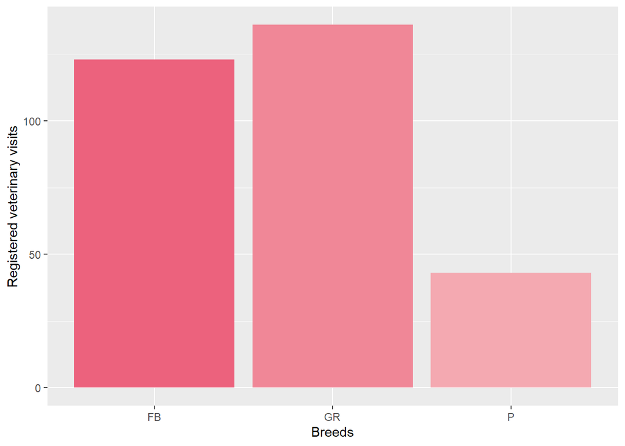

```r
# Now we can show this as a plot to show the family
#| label: fig-cases
#| fig-cap: "Number of registered veterinary visits by breed"
#| fig-width: 8
#| fig-height: 4
library(ggplot2)
ggplot(MedicalConditions_table, aes(x = Value, y = Count)) +
  geom_bar(stat = "identity", fill = unibePastelS()[1:3]) +
  labs(x = "Breeds", y = "Registered veterinary visits")
```

This plot shows that indeed a Pug is the best breed for this family given the previous traits about the breed and the new medical information.

## Conclusion

Choosing the right breed of dog for adoption in families with special needs is vital for ensuring compatibility, safety, and overall well-being. Tailoring the selection to suit the family’s requirements and abilities can lead to a successful and fulfilling companionship, ensuring the quality of life for both the family and the dog.